# CodeClan Wine - Linear Regression Model Building

# 1 Introduction

This example was used as a homework exercise in CodeClan and shows two ways to build a multiple linear regression model on a synthetic, wine-based dataset.  
The data in question started life in the UCI machine learning repository, https://archive.ics.uci.edu/ml/datasets/wine+quality.

Ref: *P. Cortez, A. Cerdeira, F. Almeida, T. Matos and J. Reis. Modeling wine preferences by data mining from physicochemical properties. In Decision Support Systems, Elsevier, 47(4):547-553, 2009.*

The first modelling run will focus on a manual model build, followed by an automated build to see if there are any differences in the final model.

The wine data is contained in two datasets, namely `wine_quality_red` and `wine_quality_white`. The overall aim is to model the `quality` of the wines using linear regression to try to determine what makes a “good” wine.

There are many ways to build an explanatory model like this so this isn’t intended to be the **absolute** best answer, but shows in detail the regression model building process in R.

## 1.1 Data & Data Cleaning

Load libraries:

```r
library(tidyverse)
library(GGally)
library(modelr)
library(janitor)
library(here)
library(ggfortify)
library(performance)
library(see)
library(leaps)
```

Read the data for red wine;

```r
wine_red <- read_csv(here("data/wine_quality_red.csv"))
head(wine_red)
```

| wine_id | fixed_acidity | volatile_acidity | citric_acid | residual_sugar | chlorides | free_sulfur_dioxide | total_sulfur_dioxide | density | p_h | sulphates | alcohol | quality | region |
| --- | --- | --- | --- | --- | --- | --- | --- | --- | --- | --- | --- | --- | --- |
| 1 | 7.4 | 0.70 | 0.00 | 1.9 | 0.076 | 11 | 34 | 0.9978 | 3.51 | 0.56 | 9.4 | 4.66 | Australia |
| 2 | 7.8 | 0.88 | 0.00 | 2.6 | 0.098 | 25 | 67 | 0.9968 | 3.20 | 0.68 | 9.8 | 4.82 | Spain |
| 3 | 7.8 | 0.76 | 0.04 | 2.3 | 0.092 | 15 | 54 | 0.9970 | 3.26 | 0.65 | 9.8 | 4.91 | Spain |
| 4 | 11.2 | 0.28 | 0.56 | 1.9 | 0.075 | 17 | 60 | 0.9980 | 3.16 | 0.58 | 9.8 | 5.96 | Australia |
| 5 | 7.4 | 0.70 | 0.00 | 1.9 | 0.076 | 11 | 34 | 0.9978 | 3.51 | 0.56 | 9.4 | 5.42 | Italy |
| 6 | 7.4 | 0.66 | 0.00 | 1.8 | 0.075 | 13 | 40 | 0.9978 | 3.51 | 0.56 | 9.4 | 4.78 | Italy |

So there’s an ID column and 13 variables including `quality`.

Read in the white wine data;

```r
wine_white <- read_csv(here("data/wine_quality_white.csv"))
head(wine_white)
```

| wine_id | fixed_acidity | volatile_acidity | citric_acid | residual_sugar | chlorides | free_sulfur_dioxide | total_sulfur_dioxide | density | p_h | sulphates | alcohol | quality | region |
| --- | --- | --- | --- | --- | --- | --- | --- | --- | --- | --- | --- | --- | --- |
| 1 | 7.0 | 0.27 | 0.36 | 20.7 | 0.045 | 45 | 170 | 1.0010 | 3.00 | 0.45 | 8.8 | 5.92 | Australia |
| 2 | 6.3 | 0.30 | 0.34 | 1.6 | 0.049 | 14 | 132 | 0.9940 | 3.30 | 0.49 | 9.5 | 6.06 | Australia |
| 3 | 8.1 | 0.28 | 0.40 | 6.9 | 0.050 | 30 | 97 | 0.9951 | 3.26 | 0.44 | 10.1 | 6.25 | Spain |
| 4 | 7.2 | 0.23 | 0.32 | 8.5 | 0.058 | 47 | 186 | 0.9956 | 3.19 | 0.40 | 9.9 | 6.38 | Spain |
| 5 | 7.2 | 0.23 | 0.32 | 8.5 | 0.058 | 47 | 186 | 0.9956 | 3.19 | 0.40 | 9.9 | 6.35 | USA |
| 6 | 8.1 | 0.28 | 0.40 | 6.9 | 0.050 | 30 | 97 | 0.9951 | 3.26 | 0.44 | 10.1 | 5.82 | Italy |

This is in the same format as the red wine data, with the same variables. This suggests that joining the two datasets with a colour identifying column could be one way to handle both sets of data simultaneously.

First of all, create the colour identifying columns;

```r
wine_red <- wine_red %>%
  mutate(wine_colour = "red", .before = fixed_acidity)

wine_white <- wine_white %>%
  mutate(wine_colour = "white", .before = fixed_acidity)
```

If the two datasets are to be combined then the `wine_id` number needs to be handled to avoid duplicates. The `wine_id` isn’t something that necessarily reflects the physiochemical properties of a “good” wine, so could probably be removed completely upon joining the datasets.

```r
# first join white wine to red wine;
wine_all <- bind_rows(wine_red, wine_white)

# then remove wine_id
wine_all <- wine_all %>%
  select(-wine_id)
```

Apart from wine colour, there’s only one categorical data column which might need to be converted to a factor for the purposes of regression - `region`.  
Check how many discrete values are involved;

```r
wine_all %>%
  distinct(region) %>%
  summarise(number_of_regions = n())
```

| number_of_regions |
| --- |
| 5 |

So there are five regions; Australia, Spain, Italy, USA, France. These and the wine colour should be changed to factor data;

```r
wine_all <- wine_all %>%
  mutate(region = as.factor(region),
         wine_colour = as.factor(wine_colour))

# and check;
# class(wine_all$region)
# class(wine_all$wine_colour)
```

Now check for aliased variables (i.e. combinations of variables in which one or more of the variables can be calculated from other variables):

```r
alias(quality ~ ., data = wine_all)
```

```
## Model :
## quality ~ wine_colour + fixed_acidity + volatile_acidity + citric_acid +
##     residual_sugar + chlorides + free_sulfur_dioxide + total_sulfur_dioxide +
##     density + p_h + sulphates + alcohol + region
```

There are no obvious aliases returned, but some sound very similar (e.g. `fixed_acidity` and `volatile_acidity`, `free_sulfur_dioxide` and `total_sulfur_dioxide`) so it’s worth watching these as the regression progresses.

## 1.2 First predictor variable

`GGally::ggpairs()` is a useful tool for deciding which variable to pick as a predictor, but can take some time to run. This can be mitigated by splitting up the data beforehand;

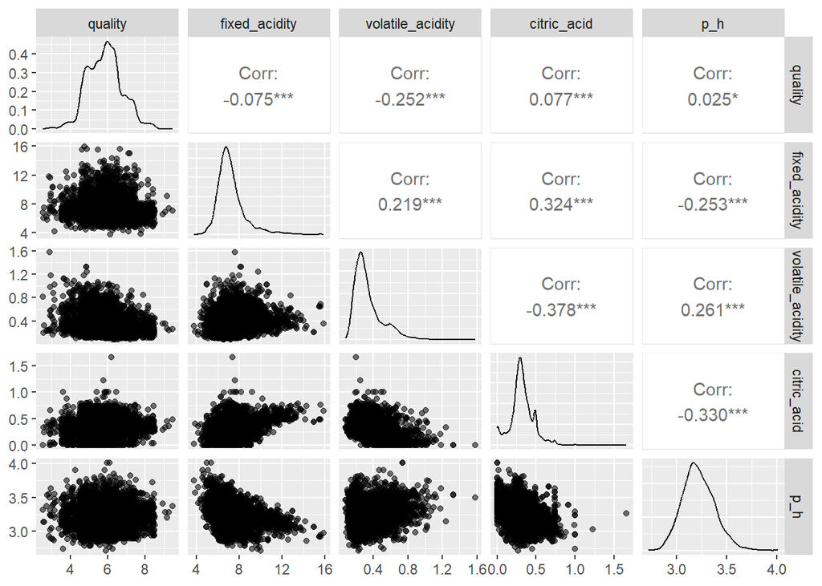

```r
# start with quality and acidity variables
wine_all %>%
  select(quality, fixed_acidity, volatile_acidity, citric_acid, p_h) %>%
  ggpairs(aes(alpha = 0.3))
```

Despite initial misgivings it looks like the acidity variables are not especially correlated with each other so there’s no justification to remove them.

The highest correlation with `quality` is `volatile_acidity`, but it is weak at -0.25.

Look at the remaining variables;

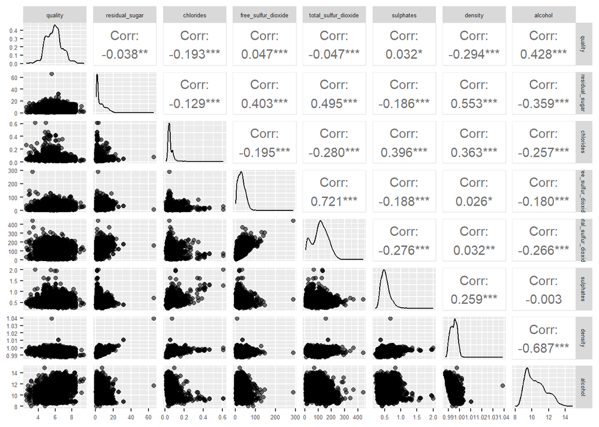

```r
wine_all %>%
  select(quality, residual_sugar, chlorides, free_sulfur_dioxide, total_sulfur_dioxide, sulphates, density, alcohol) %>%
  ggpairs(aes(alpha = 0.3)) +
  theme(text= element_text(size = 6)) # make headers more legible
```

It’s also clear that `total_sulfur_dioxide` is strongly correlated with `free_sulfur_dioxide` so for modelling only consider `total_sulfur_dioxide`.

```r
wine_all <- wine_all %>%
  select(-density, -free_sulfur_dioxide)
```

With the aim of modelling against `quality`, `alcohol` returns a moderate correlation of 0.4 and `chlorides` a weak correlation of 0.2.

Next, consider the categorical variables, `wine_colour` and `region`:

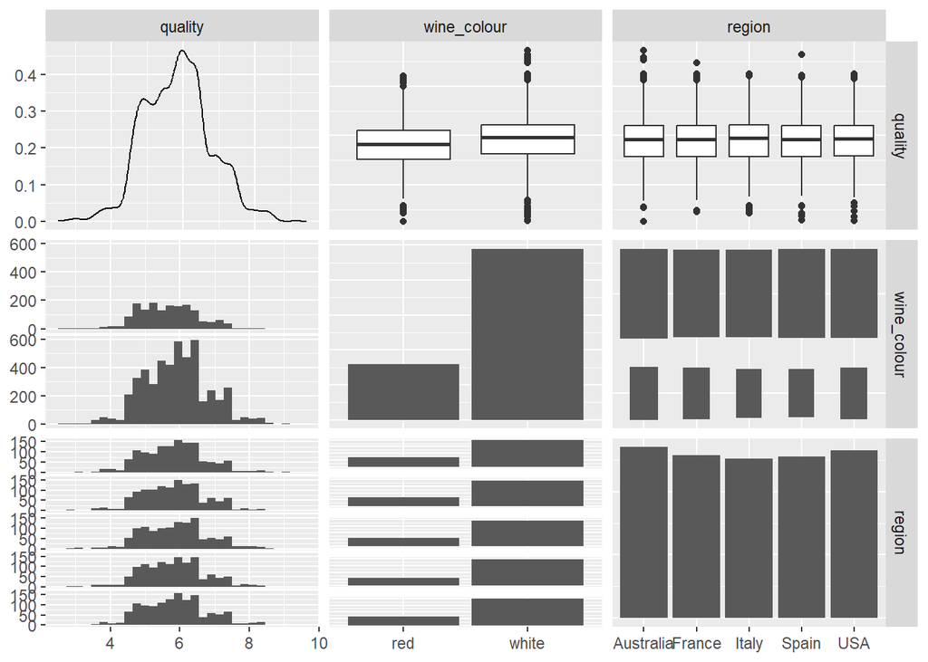

```r
wine_all %>%
  select(quality, wine_colour, region) %>%
  ggpairs()
```

These plots suggest no practical correlation between `quality` and either `region` or `colour`.

For a first model our largest correlation coefficients came from `alcohol`, `chlorides`, and `volatile_acidity`.

Taking these individually and comparing;

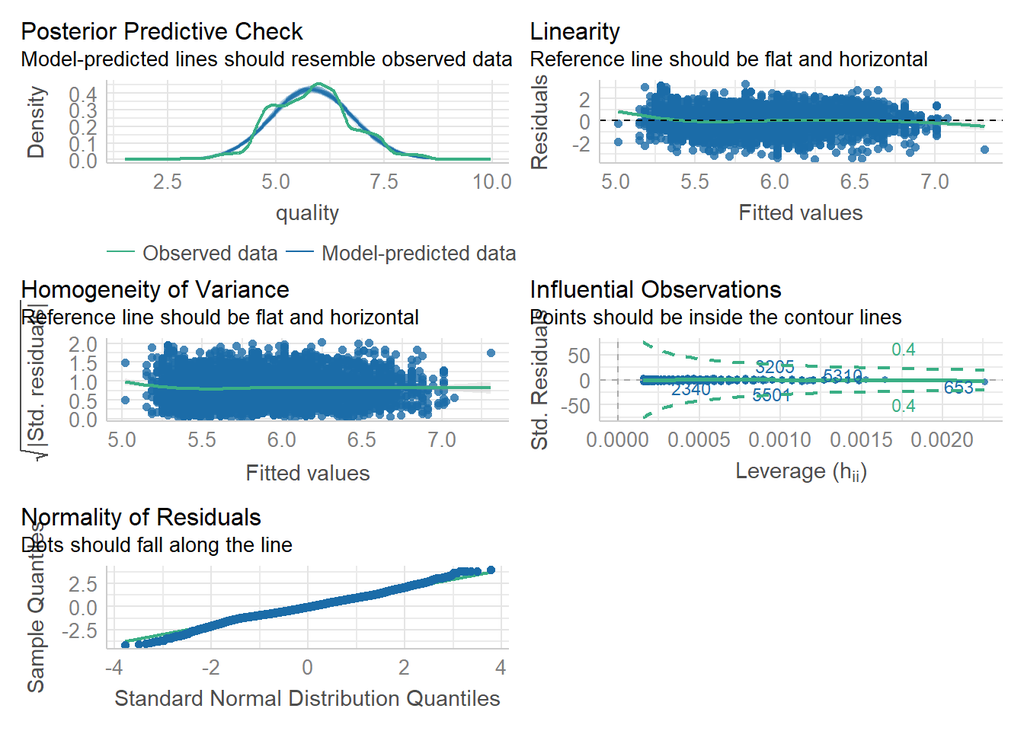

```r
# define the model with the first predictor variable
mod1a <- lm(quality ~ alcohol, data = wine_all)

# check the diagnostics
check_model(mod1a)
```

```r
# check the summary
summary(mod1a)
```

```
##
## Call:
## lm(formula = quality ~ alcohol, data = wine_all)
##
## Residuals:
##     Min      1Q  Median      3Q     Max
## -3.4852 -0.5552 -0.0293  0.5507  3.3362
##
## Coefficients:
##             Estimate Std. Error t value Pr(>|t|)
## (Intercept) 2.362872   0.091794   25.74   <2e-16 ***
## alcohol     0.331822   0.008693   38.17   <2e-16 ***
## ---
## Signif. codes:  0 '***' 0.001 '**' 0.01 '*' 0.05 '.' 0.1 ' ' 1
##
## Residual standard error: 0.8357 on 6495 degrees of freedom
## Multiple R-squared:  0.1832, Adjusted R-squared:  0.1831
## F-statistic:  1457 on 1 and 6495 DF,  p-value: < 2.2e-16
```

The diagnostic plots don’t give any reason for concern at this stage. Now check what `chlorides` looks like.

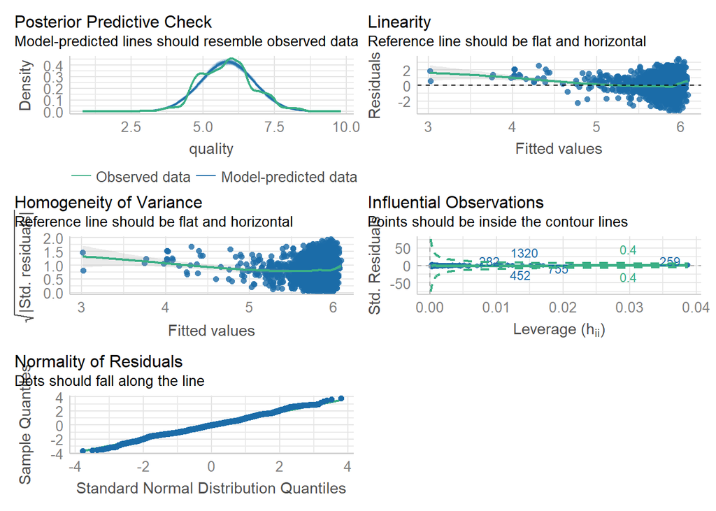

```r
# define the model
mod1b <- lm(quality ~ chlorides, data = wine_all)

# check the diagnostics
check_model(mod1b)
```

```r
# check the summary output
summary(mod1b)
```

```
##
## Call:
## lm(formula = quality ~ chlorides, data = wine_all)
##
## Residuals:
##     Min      1Q  Median      3Q     Max
## -3.3609 -0.6331  0.0073  0.5350  3.4733
##
## Coefficients:
##             Estimate Std. Error t value Pr(>|t|)
## (Intercept)  6.12974    0.02123  288.69   <2e-16 ***
## chlorides   -5.09449    0.32131  -15.86   <2e-16 ***
## ---
## Signif. codes:  0 '***' 0.001 '**' 0.01 '*' 0.05 '.' 0.1 ' ' 1
##
## Residual standard error: 0.9073 on 6495 degrees of freedom
## Multiple R-squared:  0.03726,    Adjusted R-squared:  0.03711
## F-statistic: 251.4 on 1 and 6495 DF,  p-value: < 2.2e-16
```

In this case homogeneity and linearity are not ideal. Is this due to outliers?

```r
check_outliers(mod1b)
```

```
## OK: No outliers detected.
## - Based on the following method and threshold: cook (0.7).
## - For variable: (Whole model)
```

or non-normal residuals distribution?

```r
check_normality(mod1b)
```

[output not shown]

This may explain some of the “imperfect” diagnostic plots.

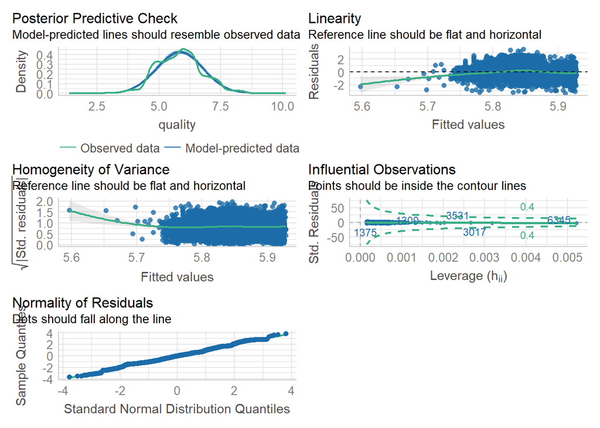

```r
# define the model
mod1c <- lm(quality ~ total_sulfur_dioxide, data = wine_all)

# check the diagnostics
check_model(mod1c)
```

```r
# check the summary output
summary(mod1c)
```

```
##
## Call:
## lm(formula = quality ~ total_sulfur_dioxide, data = wine_all)
##
## Residuals:
##     Min      1Q  Median      3Q     Max
## -3.3804 -0.6826  0.0118  0.5615  3.5936
##
## Coefficients:
##                        Estimate Std. Error t value Pr(>|t|)
## (Intercept)           5.9325600  0.0261160 227.162  < 2e-16 ***
## total_sulfur_dioxide -0.0007627  0.0002028  -3.762  0.00017 ***
## ---
## Signif. codes:  0 '***' 0.001 '**' 0.01 '*' 0.05 '.' 0.1 ' ' 1
##
## Residual standard error: 0.9237 on 6495 degrees of freedom
## Multiple R-squared:  0.002174,   Adjusted R-squared:  0.00202
## F-statistic: 14.15 on 1 and 6495 DF,  p-value: 0.0001701
```

Once again homogeneity and linearity don’t look ideal.

```r
check_outliers(mod1b)
```

```
## OK: No outliers detected.
## - Based on the following method and threshold: cook (0.7).
## - For variable: (Whole model)
```

```r
check_normality(mod1b)
```

[output not shown]

Once again this is due to non-normally distributed residuals.

This suggests that `alcohol` is the best choice as a first predictor variable for the model.

`ggpairs()` can now be re-run with the residuals to try to identify a good second predictor.

## 1.3 Second predictor variable

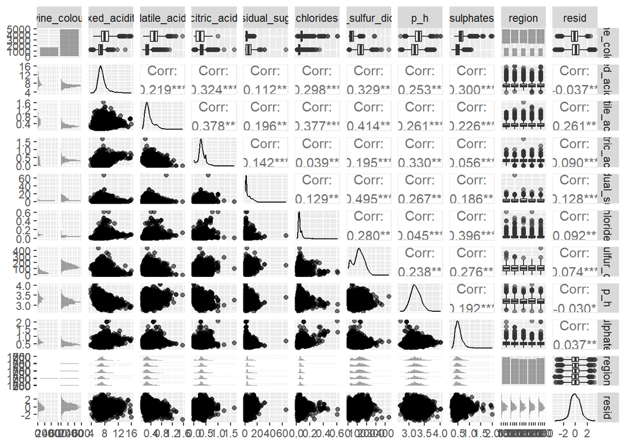

```r
wine_residuals <- wine_all %>%
  add_residuals(mod1a) %>%
  select(-c("quality", "alcohol")) # remove the variables already in the model

ggpairs(wine_residuals, aes(alpha = 0.3))
```

There aren’t any immediately obvious strong correlations between any numeric variables here.

`chlorides` once again looks feasible, as do `volatile_acidity` and `residual_sugar` for a second predictor.

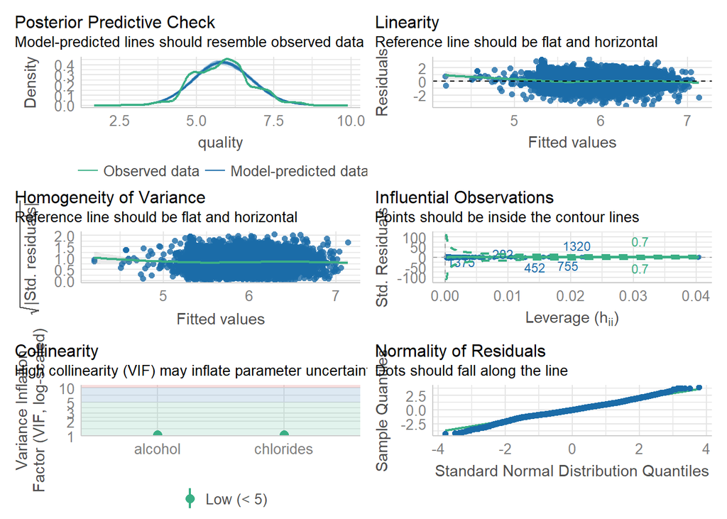

```r
# define the model
mod2a <- lm(quality ~ alcohol + chlorides, data = wine_all)
# check the diagnostics
check_model(mod2a)
```

```r
# Summarise
summary(mod2a)
```

```
##
## Call:
## lm(formula = quality ~ alcohol + chlorides, data = wine_all)
##
## Residuals:
##     Min      1Q  Median      3Q     Max
## -3.5272 -0.5522 -0.0290  0.5412  3.2852
##
## Coefficients:
##              Estimate Std. Error t value Pr(>|t|)
## (Intercept)  2.680219   0.100251  26.735  < 2e-16 ***
## alcohol      0.314110   0.008955  35.077  < 2e-16 ***
## chlorides   -2.347084   0.304869  -7.699 1.58e-14 ***
## ---
## Signif. codes:  0 '***' 0.001 '**' 0.01 '*' 0.05 '.' 0.1 ' ' 1
##
## Residual standard error: 0.8319 on 6494 degrees of freedom
## Multiple R-squared:  0.1906, Adjusted R-squared:  0.1904
## F-statistic: 764.7 on 2 and 6494 DF,  p-value: < 2.2e-16
```

This returns an adjusted R^2 of around 0.19, suggesting that these predictors could account for approximately 19% of the variation in our data. Chlorides is also shown to be statistically significant in this model.

What does `volatile acidity` look like:

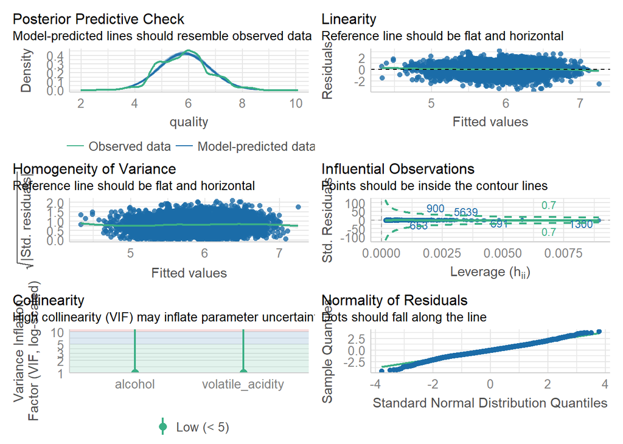

```r
# define the model
mod2b <- lm(quality ~ alcohol + volatile_acidity, data = wine_all)

# check the diagnostics
check_model(mod2b)
```

```r
# summarise
summary(mod2b)
```

```
##
## Call:
## lm(formula = quality ~ alcohol + volatile_acidity, data = wine_all)
##
## Residuals:
##     Min      1Q  Median      3Q     Max
## -3.6091 -0.5231 -0.0097  0.5187  3.2431
##
## Coefficients:
##                   Estimate Std. Error t value Pr(>|t|)
## (Intercept)       2.885721   0.091803   31.43   <2e-16 ***
## alcohol           0.324930   0.008398   38.69   <2e-16 ***
## volatile_acidity -1.326428   0.060840  -21.80   <2e-16 ***
## ---
## Signif. codes:  0 '***' 0.001 '**' 0.01 '*' 0.05 '.' 0.1 ' ' 1
##
## Residual standard error: 0.8067 on 6494 degrees of freedom
## Multiple R-squared:  0.2389, Adjusted R-squared:  0.2387
## F-statistic:  1019 on 2 and 6494 DF,  p-value: < 2.2e-16
```

This looks better than `chlorides`, explaining around 23% of the variation in our data.

Check `residual_sugar`;

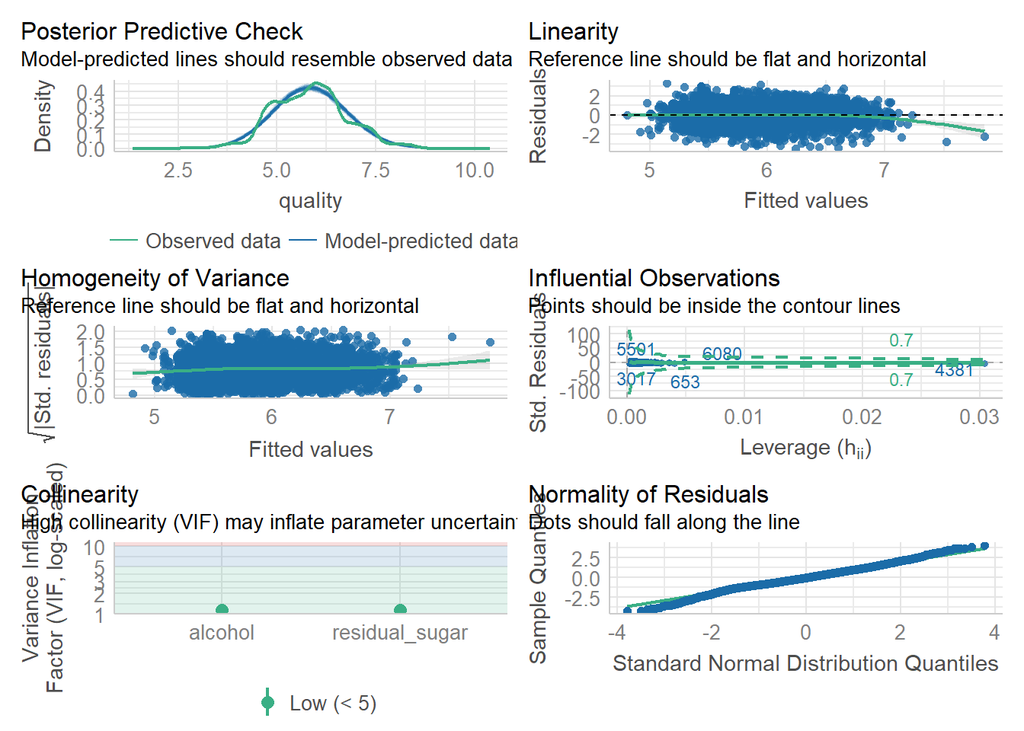

```r
# define the model
mod2c <- lm(quality ~ alcohol + residual_sugar, data = wine_all)

# check diagnostics
check_model(mod2c)
```

```r
# summarise
summary(mod2c)
```

```
##
## Call:
## lm(formula = quality ~ alcohol + residual_sugar, data = wine_all)
##
## Residuals:
##     Min      1Q  Median      3Q     Max
## -3.4797 -0.5469 -0.0265  0.5340  3.3382
##
## Coefficients:
##                Estimate Std. Error t value Pr(>|t|)
## (Intercept)    1.834135   0.102542   17.89   <2e-16 ***
## alcohol        0.368826   0.009228   39.97   <2e-16 ***
## residual_sugar 0.025810   0.002313   11.16   <2e-16 ***
## ---
## Signif. codes:  0 '***' 0.001 '**' 0.01 '*' 0.05 '.' 0.1 ' ' 1
##
## Residual standard error: 0.8278 on 6494 degrees of freedom
## Multiple R-squared:  0.1986, Adjusted R-squared:  0.1983
## F-statistic: 804.6 on 2 and 6494 DF,  p-value: < 2.2e-16
```

It looks like `mod2b` using `alcohol` and `volatile_acidity` comes out as the best option for a second predictor. It’s worth noting however that although `chlorides` and `residual_sugar` did not perform as well, they do still have significant p-values (both at < 0.001).

Is it justifiable to make a more complex model (i.e. single predictor vs two predictors)? Check using ANOVA (ANalysis Of VAriables).

mod1a = quality ~ alcohol mod2b = quality ~ alcohol + volatile_acidity

We want to compare the two;

```r
anova(mod1a, mod2b)
```

|  | Res.Df | RSS | Df | Sum of Sq | F | Pr(>F) |
| --- | --- | --- | --- | --- | --- | --- |
| 1 | 6495 | 4535.712 | NA | NA | NA | NA |
| 2 | 6494 | 4226.362 | 1 | 309.3499 | 475.3304 | 9.202137e-102 |

The addition of `volatile_acidity` in mod2b creates a better model with a lower Residual Sum of Squares, low p-value and high significance.

Even adding this significant predictor didn’t give much of an increase in adjusted R^2, so adding more and more predictors is only likely to return ever decreasing marginal increases in the model’s ability to explain variation.

It could be that there’s an interaction between our current predictor variables, so it would be worth investigating that;

## 1.4 Pair interaction

Let’s now think about possible pair interactions: for two main effect variables (`alcohol + volatile_acidity`) we have one possible pair interaction.

```r
mod_interaction <- lm(quality ~ alcohol + volatile_acidity + alcohol:volatile_acidity, data = wine_all)
summary(mod_interaction)
```

```
##
## Call:
## lm(formula = quality ~ alcohol + volatile_acidity + alcohol:volatile_acidity,
##     data = wine_all)
##
## Residuals:
##     Min      1Q  Median      3Q     Max
## -3.5809 -0.5235 -0.0102  0.5120  3.2422
##
## Coefficients:
##                          Estimate Std. Error t value Pr(>|t|)
## (Intercept)               3.65954    0.22658  16.151  < 2e-16 ***
## alcohol                   0.25035    0.02166  11.559  < 2e-16 ***
## volatile_acidity         -3.58654    0.60818  -5.897 3.88e-09 ***
## alcohol:volatile_acidity  0.21829    0.05845   3.735 0.000189 ***
## ---
## Signif. codes:  0 '***' 0.001 '**' 0.01 '*' 0.05 '.' 0.1 ' ' 1
##
## Residual standard error: 0.8059 on 6493 degrees of freedom
## Multiple R-squared:  0.2406, Adjusted R-squared:  0.2402
## F-statistic: 685.6 on 3 and 6493 DF,  p-value: < 2.2e-16
```

Adding this interaction only adds a tiny amount to the adjusted R^2. It might be worth checking using ANOVA if including this interaction in the model is justified:

```r
#  Justified in adding this interaction!
anova(mod2b, mod_interaction)
```

|  | Res.Df | RSS | Df | Sum of Sq | F | Pr(>F) |
| --- | --- | --- | --- | --- | --- | --- |
| 1 | 6494 | 4226.362 | NA | NA | NA | NA |
| 2 | 6493 | 4217.302 | 1 | 9.060348 | 13.9494 | 0.0001894062 |

The interaction is significant, so the final model is:

`quality ~ alcohol + volatile_acidity + alcohol:volatile_acidity`

The model only explains around 24% of the variation in our data, but it might still be useful depending on the context of the data and situation it’s being applied to.

It would have been possible to have continued to add predictors for diminishing returns, or alternatively the model building process could have been performed in a more automated way, as shown briefly below;

## 1.5 Automated approach using `leaps`

The `leaps` package could be used to make a predictive model using a more automated workflow.

First of all set up the `regsubsets` function to try adding all predictors to a model and show which are the most “powerful” contributors;

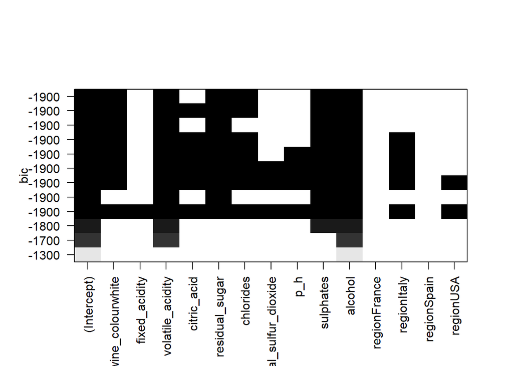

```r
regsubsets_forward <- regsubsets(quality ~ ., # use all of the possible variables
                                 data = wine_all,
                                 nvmax = 12, # model can have max of 12 predictors
                                 method = "forward" # forward selection
                                 )

plot(regsubsets_forward)
```

This resulting plot indicates that the best performing model (i.e. top row) uses `wine_colourwhite`,`volatile_acidity`, `residual_sugar`, `chlorides`, `sulphates`, and `alcohol`.

```r
summary(regsubsets_forward)$which[6,]
```

```
##          (Intercept)     wine_colourwhite        fixed_acidity
##                 TRUE                 TRUE                FALSE
##     volatile_acidity          citric_acid       residual_sugar
##                 TRUE                FALSE                 TRUE
##            chlorides total_sulfur_dioxide                  p_h
##                 TRUE                FALSE                FALSE
##            sulphates              alcohol         regionFrance
##                 TRUE                 TRUE                FALSE
##          regionItaly          regionSpain            regionUSA
##                FALSE                FALSE                FALSE
```

The bIC scores can also be plotted to check predictor performance;

```r
sum_regsubsets_forward <- summary(regsubsets_forward)

sum_regsubsets_forward$bic
```

```
##  [1] -1297.376 -1747.548 -1806.253 -1864.377 -1892.755 -1894.956 -1893.473
##  [8] -1889.314 -1884.496 -1879.625 -1871.791 -1863.431
```

And then plot the BIC scores;

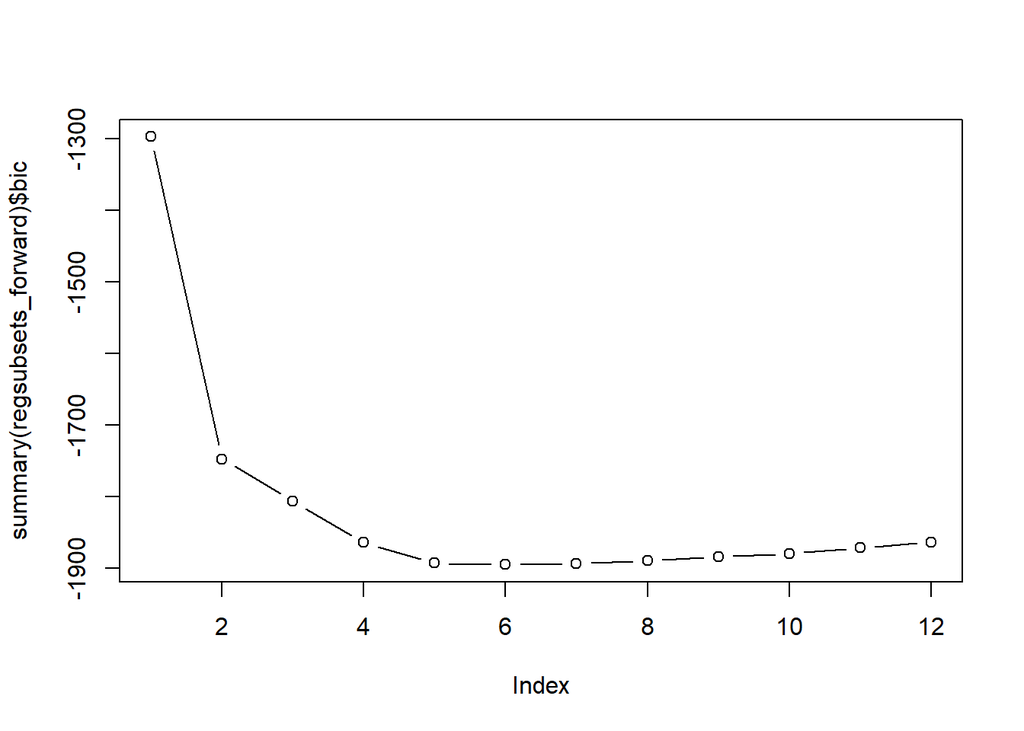

```r
plot(summary(regsubsets_forward)$bic, type = "b")
```

This plot suggests that the BIC score is lowest using 6 different predictor variables in the model. We can check which variables these are:

```r
sum_regsubsets_forward$which[6, ]
```

```
##          (Intercept)     wine_colourwhite        fixed_acidity
##                 TRUE                 TRUE                FALSE
##     volatile_acidity          citric_acid       residual_sugar
##                 TRUE                FALSE                 TRUE
##            chlorides total_sulfur_dioxide                  p_h
##                 TRUE                FALSE                FALSE
##            sulphates              alcohol         regionFrance
##                 TRUE                 TRUE                FALSE
##          regionItaly          regionSpain            regionUSA
##                FALSE                FALSE                FALSE
```

This means that the automated model build has suggested a model with `wine_colourwhite`,`volatile_acidity`, `residual_sugar`, `chlorides`, `sulphates`, and `alcohol`.

This is more predictors than the previous manual model build, but there is often no single ‘correct’ answer in regression modelling.

What about if we limited it to two predictors?

```r
sum_regsubsets_forward$which[2, ]
```

```
##          (Intercept)     wine_colourwhite        fixed_acidity
##                 TRUE                FALSE                FALSE
##     volatile_acidity          citric_acid       residual_sugar
##                 TRUE                FALSE                FALSE
##            chlorides total_sulfur_dioxide                  p_h
##                FALSE                FALSE                FALSE
##            sulphates              alcohol         regionFrance
##                FALSE                 TRUE                FALSE
##          regionItaly          regionSpain            regionUSA
##                FALSE                FALSE                FALSE
```

The best two predictors are suggested as `volatile_acidity` and `alcohol`.

**i.e. the same conclusion as using the manual method (before adding the interaction)**

The `leaps` package doesn’t include interactions, but they could be included in the same way as shown during the manual modelling above.